# IntroComp_Weixuan_Chen_HW8-10

Weixuan Chen

4/2/2023

## Data Preparation

```r
data("mtcars")
mtcars
```

```
##                      mpg cyl  disp  hp drat    wt  qsec vs am gear carb
## Mazda RX4           21.0   6 160.0 110 3.90 2.620 16.46  0  1    4    4
## Mazda RX4 Wag       21.0   6 160.0 110 3.90 2.875 17.02  0  1    4    4
## Datsun 710          22.8   4 108.0  93 3.85 2.320 18.61  1  1    4    1
## Hornet 4 Drive      21.4   6 258.0 110 3.08 3.215 19.44  1  0    3    1
## Hornet Sportabout   18.7   8 360.0 175 3.15 3.440 17.02  0  0    3    2
## Valiant             18.1   6 225.0 105 2.76 3.460 20.22  1  0    3    1
## Duster 360          14.3   8 360.0 245 3.21 3.570 15.84  0  0    3    4
## Merc 240D           24.4   4 146.7  62 3.69 3.190 20.00  1  0    4    2
## Merc 230            22.8   4 140.8  95 3.92 3.150 22.90  1  0    4    2
## Merc 280            19.2   6 167.6 123 3.92 3.440 18.30  1  0    4    4
## Merc 280C           17.8   6 167.6 123 3.92 3.440 18.90  1  0    4    4
## Merc 450SE          16.4   8 275.8 180 3.07 4.070 17.40  0  0    3    3
## Merc 450SL          17.3   8 275.8 180 3.07 3.730 17.60  0  0    3    3
## Merc 450SLC         15.2   8 275.8 180 3.07 3.780 18.00  0  0    3    3
## Cadillac Fleetwood  10.4   8 472.0 205 2.93 5.250 17.98  0  0    3    4
## Lincoln Continental 10.4   8 460.0 215 3.00 5.424 17.82  0  0    3    4
## Chrysler Imperial   14.7   8 440.0 230 3.23 5.345 17.42  0  0    3    4
## Fiat 128            32.4   4  78.7  66 4.08 2.200 19.47  1  1    4    1
## Honda Civic         30.4   4  75.7  52 4.93 1.615 18.52  1  1    4    2
## Toyota Corolla      33.9   4  71.1  65 4.22 1.835 19.90  1  1    4    1
## Toyota Corona       21.5   4 120.1  97 3.70 2.465 20.01  1  0    3    1
## Dodge Challenger    15.5   8 318.0 150 2.76 3.520 16.87  0  0    3    2
## AMC Javelin         15.2   8 304.0 150 3.15 3.435 17.30  0  0    3    2
## Camaro Z28          13.3   8 350.0 245 3.73 3.840 15.41  0  0    3    4
## Pontiac Firebird    19.2   8 400.0 175 3.08 3.845 17.05  0  0    3    2
## Fiat X1-9           27.3   4  79.0  66 4.08 1.935 18.90  1  1    4    1
## Porsche 914-2       26.0   4 120.3  91 4.43 2.140 16.70  0  1    5    2
## Lotus Europa        30.4   4  95.1 113 3.77 1.513 16.90  1  1    5    2
## Ford Pantera L      15.8   8 351.0 264 4.22 3.170 14.50  0  1    5    4
## Ferrari Dino        19.7   6 145.0 175 3.62 2.770 15.50  0  1    5    6
## Maserati Bora       15.0   8 301.0 335 3.54 3.570 14.60  0  1    5    8
## Volvo 142E          21.4   4 121.0 109 4.11 2.780 18.60  1  1    4    2
```

## 1

In this homework we will build models to predict miles per gallon (MPG) from mtcars dataset. We will evaluate suitable regressors with final goal to answer these following questions:

1. Is an automatic or manual transmission better for MPG?
2. Quantify the MPG difference between automatic and manual transmissions

Tests: H0: There is no difference in mpg value between automatic and manual transmission. H1: There is a difference in mpg value between both transmission types.

## 2

General Data Description: The data was extracted from the 1974 Motor Trend US magazine, and comprises fuel consumption and 10 aspects of automobile design and performance for 32 automobiles (1973–74 models).

Source: The data is the built-in dataset in r

Contents:

mpg: Miles/(US) gallon cyl: Number of cylinders disp: Displacement (cu.in.) hp: Gross horsepower drat: Rear axle ratio wt: Weight (1000 lbs) qsec: 1/4 mile time vs: Engine (0 = V-shaped, 1 = straight) am: Transmission (0 = automatic, 1 = manual) gear: Number of forward gears

## 4

```r
library(dplyr)
glimpse(mtcars)
```

```
## Rows: 32
## Columns: 11
## $ mpg  <dbl> 21.0, 21.0, 22.8, 21.4, 18.7, 18.1, 14.3, 24.4, 22.8, 19.2, 17.8,…
## $ cyl  <dbl> 6, 6, 4, 6, 8, 6, 8, 4, 4, 6, 6, 8, 8, 8, 8, 8, 8, 4, 4, 4, 4, 8,…
## $ disp <dbl> 160.0, 160.0, 108.0, 258.0, 360.0, 225.0, 360.0, 146.7, 140.8, 16…
## $ hp   <dbl> 110, 110, 93, 110, 175, 105, 245, 62, 95, 123, 123, 180, 180, 180…
## $ drat <dbl> 3.90, 3.90, 3.85, 3.08, 3.15, 2.76, 3.21, 3.69, 3.92, 3.92, 3.92,…
## $ wt   <dbl> 2.620, 2.875, 2.320, 3.215, 3.440, 3.460, 3.570, 3.190, 3.150, 3.…
## $ qsec <dbl> 16.46, 17.02, 18.61, 19.44, 17.02, 20.22, 15.84, 20.00, 22.90, 18…
## $ vs   <dbl> 0, 0, 1, 1, 0, 1, 0, 1, 1, 1, 1, 0, 0, 0, 0, 0, 0, 1, 1, 1, 1, 0,…
## $ am   <dbl> 1, 1, 1, 0, 0, 0, 0, 0, 0, 0, 0, 0, 0, 0, 0, 0, 0, 1, 1, 1, 0, 0,…
## $ gear <dbl> 4, 4, 4, 3, 3, 3, 3, 4, 4, 4, 4, 3, 3, 3, 3, 3, 3, 4, 4, 4, 3, 3,…
## $ carb <dbl> 4, 4, 1, 1, 2, 1, 4, 2, 2, 4, 4, 3, 3, 3, 4, 4, 4, 1, 2, 1, 1, 2,…
```

So, my independent variables are:

```r
colnames(mtcars[2:11])
```

```
##  [1] "cyl"  "disp" "hp"   "drat" "wt"   "qsec" "vs"   "am"   "gear" "carb"
```

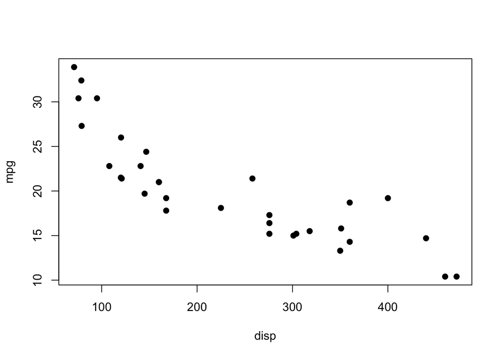

```r
plot(mtcars$disp, mtcars$mpg, xlab = "disp", ylab = "mpg", pch=19)
```

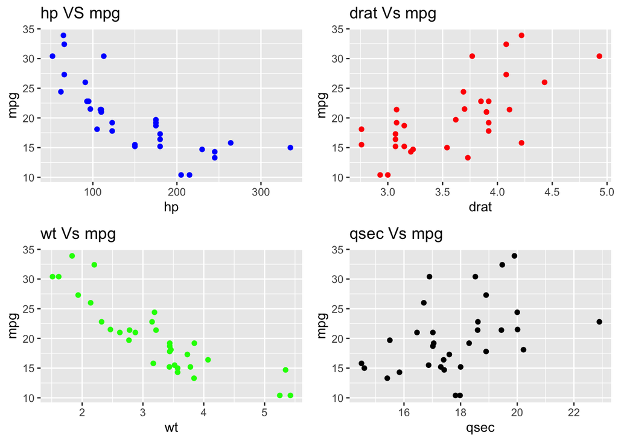

```r
df3 <- par(no.readonly = T)
par(mfrow = c(4,4))
library(ggplot2)
library(gridExtra)
p1 <- ggplot(data = mtcars) +
    geom_point(mapping = aes(x=mtcars$hp, y=mtcars$mpg), color='blue')+
    xlab("hp") + ylab("mpg") +
    ggtitle("hp VS mpg")

p2 <- ggplot(data = mtcars) +
  geom_point(mapping = aes(x=mtcars$drat, y=mtcars$mpg), color='red')+
  xlab("drat") + ylab("mpg") +
  ggtitle("drat Vs mpg")

p3 <- ggplot(data = mtcars) +
  geom_point(mapping = aes(x=mtcars$wt, y=mtcars$mpg), color='green')+
  xlab("wt") + ylab("mpg") +
  ggtitle("wt Vs mpg")

p4 <- ggplot(data = mtcars)+
  geom_point(mapping = aes(x=mtcars$qsec, y=mtcars$mpg), color='black') +
  xlab("qsec") + ylab("mpg") +
  ggtitle("qsec Vs mpg")

grid.arrange(p1, p2, p3, p4, ncol=2)
```

I have also plotted a scatter plot of the numerical variables (excluding categorical variables) and some of them also show a slight trend.

## 5

For recoding the categorical variables, I follow the process of dummy encoding by converting it into numeric binaries of 1,0.

```r
levels(factor(mtcars$cyl))
```

```
## [1] "4" "6" "8"
```

```r
levels(factor(mtcars$am))
```

```
## [1] "0" "1"
```

```r
levels(factor(mtcars$vs))
```

```
## [1] "0" "1"
```

```r
levels(factor(mtcars$gear))
```

```
## [1] "3" "4" "5"
```

```r
levels(factor(mtcars$carb))
```

```
## [1] "1" "2" "3" "4" "6" "8"
```

```r
# Dummy coding to convert categorical variables to numeric
# For variable 'cyl'
mtcars$cyl_4 <- ifelse(mtcars$cyl == 4,1,0)
mtcars$cyl_6 <- ifelse(mtcars$cyl == 6,1,0)
mtcars$cyl_8 <- ifelse(mtcars$cyl == 8,1,0)
# For variable 'am'
mtcars$am_0 <- ifelse(mtcars$am == 0,1,0)
mtcars$am_1 <- ifelse(mtcars$am == 1,1,0)
# For variable 'vs'
mtcars$vs_0 <- ifelse(mtcars$vs == 0,1,0)
mtcars$vs_1 <- ifelse(mtcars$vs == 1,1,0)
# For variable 'gear'
mtcars$gear_3 <- ifelse(mtcars$gear == 3,1,0)
mtcars$gear_4 <- ifelse(mtcars$gear == 4,1,0)
mtcars$gear_5 <- ifelse(mtcars$gear == 5,1,0)
# For variable 'carb'
mtcars$carb_1 <- ifelse(mtcars$carb == 1,1,0)
mtcars$carb_2 <- ifelse(mtcars$carb == 2,1,0)
mtcars$carb_3 <- ifelse(mtcars$carb == 3,1,0)
mtcars$carb_4 <- ifelse(mtcars$carb == 4,1,0)
mtcars$carb_6 <- ifelse(mtcars$carb == 6,1,0)
mtcars$carb_8 <- ifelse(mtcars$carb == 8,1,0)
```

```r
head(mtcars)
```

```
##                    mpg cyl disp  hp drat    wt  qsec vs am gear carb cyl_4
## Mazda RX4         21.0   6  160 110 3.90 2.620 16.46  0  1    4    4     0
## Mazda RX4 Wag     21.0   6  160 110 3.90 2.875 17.02  0  1    4    4     0
## Datsun 710        22.8   4  108  93 3.85 2.320 18.61  1  1    4    1     1
## Hornet 4 Drive    21.4   6  258 110 3.08 3.215 19.44  1  0    3    1     0
## Hornet Sportabout 18.7   8  360 175 3.15 3.440 17.02  0  0    3    2     0
## Valiant           18.1   6  225 105 2.76 3.460 20.22  1  0    3    1     0
##                   cyl_6 cyl_8 am_0 am_1 vs_0 vs_1 gear_3 gear_4 gear_5 carb_1
## Mazda RX4             1     0    0    1    1    0      0      1      0      0
## Mazda RX4 Wag         1     0    0    1    1    0      0      1      0      0
## Datsun 710            0     0    0    1    0    1      0      1      0      1
## Hornet 4 Drive        1     0    1    0    0    1      1      0      0      1
## Hornet Sportabout     0     1    1    0    1    0      1      0      0      0
## Valiant               1     0    1    0    0    1      1      0      0      1
##                   carb_2 carb_3 carb_4 carb_6 carb_8
## Mazda RX4              0      0      1      0      0
## Mazda RX4 Wag          0      0      1      0      0
## Datsun 710             0      0      0      0      0
## Hornet 4 Drive         0      0      0      0      0
## Hornet Sportabout      1      0      0      0      0
## Valiant                0      0      0      0      0
```

```r
# Dropping Make and Type since already dummies have been created
mtcars <- subset(mtcars, select = -c(cyl, am, vs, gear, carb))
cor(mtcars)
```

```
##                mpg        disp          hp          drat          wt
## mpg     1.00000000 -0.84755138 -0.77616837  0.6811719078 -0.86765938
## disp   -0.84755138  1.00000000  0.79094859 -0.7102139272  0.88797992
## hp     -0.77616837  0.79094859  1.00000000 -0.4487591169  0.65874789
## drat    0.68117191 -0.71021393 -0.44875912  1.0000000000 -0.71244065
## wt     -0.86765938  0.88797992  0.65874789 -0.7124406467  1.00000000
## qsec    0.41868403 -0.43369788 -0.70822339  0.0912047597 -0.17471588
## cyl_4   0.80195089 -0.74509811 -0.68693983  0.6523545689 -0.70005531
## cyl_6  -0.03102167 -0.20564309 -0.19134001 -0.0109078335 -0.05500425
## cyl_8  -0.74195813  0.88474637  0.81714482 -0.6154920869  0.71608881
## am_0   -0.59983243  0.59122704  0.24320426 -0.7127111272  0.69249526
## am_1    0.59983243 -0.59122704 -0.24320426  0.7127111272 -0.69249526
## vs_0   -0.66403892  0.71041589  0.72309674 -0.4402784650  0.55491568
## vs_1    0.66403892 -0.71041589 -0.72309674  0.4402784650 -0.55491568
## gear_3 -0.63085950  0.73598151  0.40987382 -0.8280238956  0.65872216
## gear_4  0.58012305 -0.68391095 -0.65642014  0.6575997931 -0.48306003
## gear_5  0.09353606 -0.09962856  0.31190917  0.2612102699 -0.26124698
## carb_1  0.46851082 -0.41837959 -0.47586463  0.0853324753 -0.39959031
## carb_2  0.26247009 -0.12469558 -0.29459934  0.1312347535 -0.24813946
## carb_3 -0.20552712  0.11885425  0.15877204 -0.3218198179  0.21466237
## carb_4 -0.48878394  0.43163484  0.40274815 -0.0007206301  0.47615195
## carb_6 -0.01182703 -0.12621124  0.07535334  0.0079989258 -0.08341069
## carb_8 -0.15412992  0.10347288  0.50119123 -0.0193040742  0.06578674
##               qsec       cyl_4       cyl_6       cyl_8         am_0
## mpg     0.41868403  0.80195089 -0.03102167 -0.74195813 -0.599832429
## disp   -0.43369788 -0.74509811 -0.20564309  0.88474637  0.591227040
## hp     -0.70822339 -0.68693983 -0.19134001  0.81714482  0.243204257
## drat    0.09120476  0.65235457 -0.01090783 -0.61549209 -0.712711127
## wt     -0.17471588 -0.70005531 -0.05500425  0.71608881  0.692495259
## qsec    1.00000000  0.53022740  0.03862809 -0.53984416  0.229860862
## cyl_4   0.53022740  1.00000000 -0.38297084 -0.63828474 -0.473068441
## cyl_6   0.03862809 -0.38297084  1.00000000 -0.46666667 -0.024049304
## cyl_8  -0.53984416 -0.63828474 -0.46666667  1.00000000  0.472969636
## am_0    0.22986086 -0.47306844 -0.02404930  0.47296964  1.000000000
## am_1   -0.22986086  0.47306844  0.02404930 -0.47296964 -1.000000000
## vs_0   -0.74453544 -0.68802121 -0.14285714  0.77777778  0.168345125
## vs_1    0.74453544  0.68802121  0.14285714 -0.77777778 -0.168345125
## gear_3 -0.08371670 -0.54799369 -0.19408624  0.68640255  0.776991101
## gear_4  0.49160974  0.52663543  0.21469802 -0.68313005 -0.410720048
## gear_5 -0.54042206  0.05096472 -0.01951800 -0.03253000 -0.520245395
```

[output cut: 60 more lines]

```
## cyl_6  -0.09503819
## cyl_8   0.20365327
## am_0   -0.21713222
## am_1    0.21713222
## vs_0    0.15839699
## vs_1   -0.15839699
## gear_3 -0.16870980
## gear_4 -0.13912167
## gear_5  0.41736501
## carb_1 -0.09503819
## carb_2 -0.12108987
## carb_3 -0.05776713
## carb_4 -0.12108987
## carb_6 -0.03225806
## carb_8  1.00000000
```

Checking the correlation to find the relationship between independent variables.

```r
library(reshape2)
```

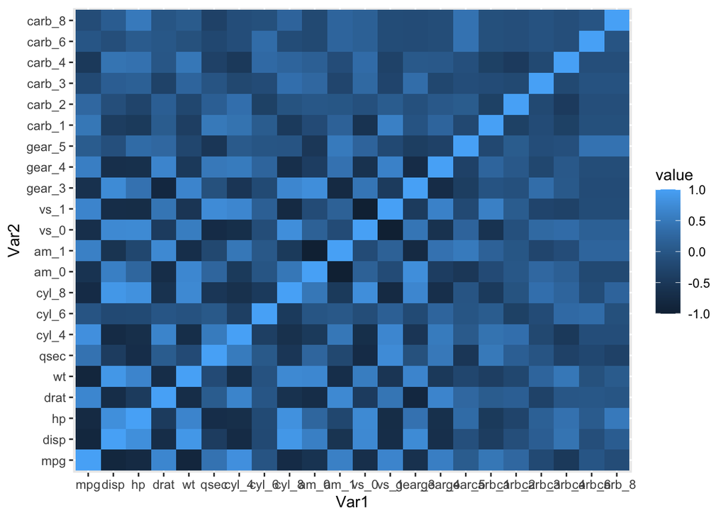

```r
melted_corr_mat <- melt(cor(mtcars))

# plotting the correlation heatmap
library(ggplot2)
ggplot(data = melted_corr_mat, aes(x=Var1, y=Var2,
                                   fill=value)) +
geom_tile()
```